# Final Q

Jake Cavaiani

12/2/22

Important NOTES: 1) Water level data is obtained from HOBO pressure transducers (PTs) that were installed in PVC pipes in streams, with the PT sitting on top of a rebar piece at bottom of pipe. Raw pressure from PTs were processed in HOBOware to correct for atmospheric pressure to get water depth. Atmospheric pressure was obtained from a PT installed at each site in a tree. HOWEVER, water depth is absolute PT depth, NOT actual water depth. To get actual water depth, we need a reference water depth from a time point in the water depth time series that is an accurate measure of the depth of the pt from the water surface. We do not have these (depth measurements from flow meter measurements were not done sufficiently close to PT locations to use).We have waterlevel surveys from Kate Broberg in 2020 and 2021 We must therefore rely on the rating curve to convert absolute water depth to continuous Q.

2. Date/time from HOBOware data is GMT-8, which is Alaska Daylight Time, which is the correct timezone for this project in summer (AK is in GMT-9 March-November when daylight savings is not observed). Data/time therefore needs to be formatted but not timezone-converted.

Step 1: import raw data hoboware files which is site, datetime, absolute pressure and water level Step 2: Clean errant points within the data that could be due to installation/decommission or gaps in data Step 3: Write final output of cleaned site, datetime, absolute pressure and water level Step 4: import Qsummary document to generate rating curves of Q and pressure Step 5: clean errant points in regression Step 6: apply rating curve to generate continuous predicted discharge at each site Step 7: Output final discharge as csv.

### French and Moose 2018 Discharge

2018 data is read from DoD->2018 sesors French Moose->Q->Qprocessing->“French_stream_PT_may-oct2018_20005933.csv” Wading rods and slugs were used to measure discrete Q during site visit

##### Checking closeness between the two Pressure Transducers

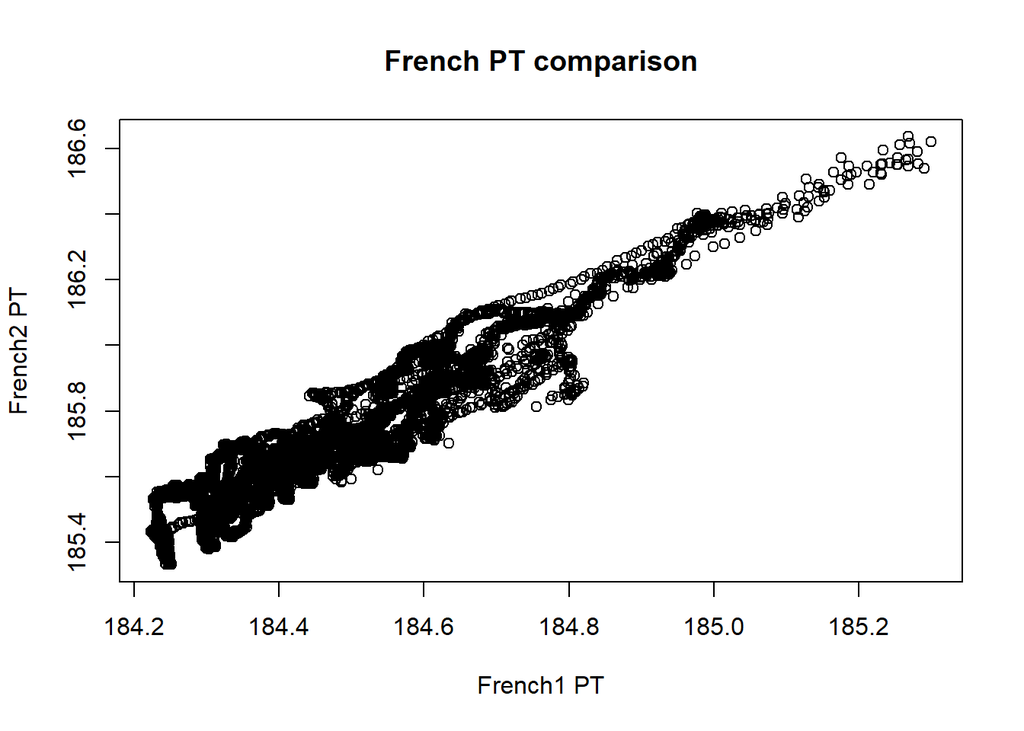

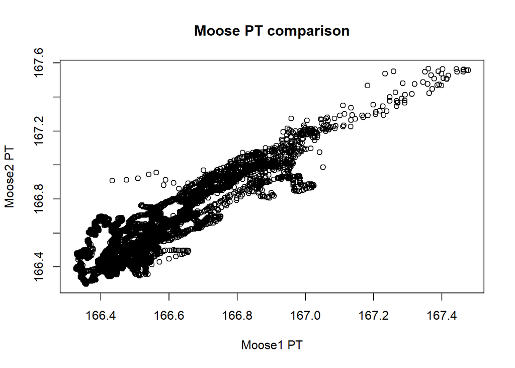

### French

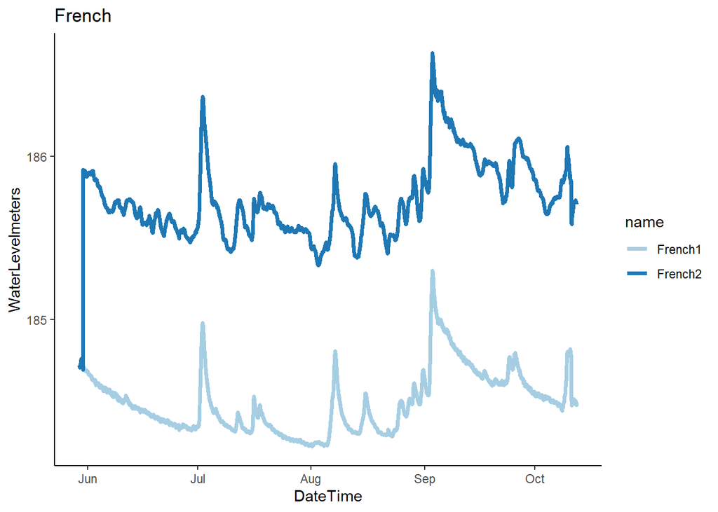

There looks like an error when we calculated depth. Tom says that we can adjust the difference of the wrong one to make them agree, then remeasure them next year. French 2 also looks “noisier” 1) dumping French 2

### Raw French 1

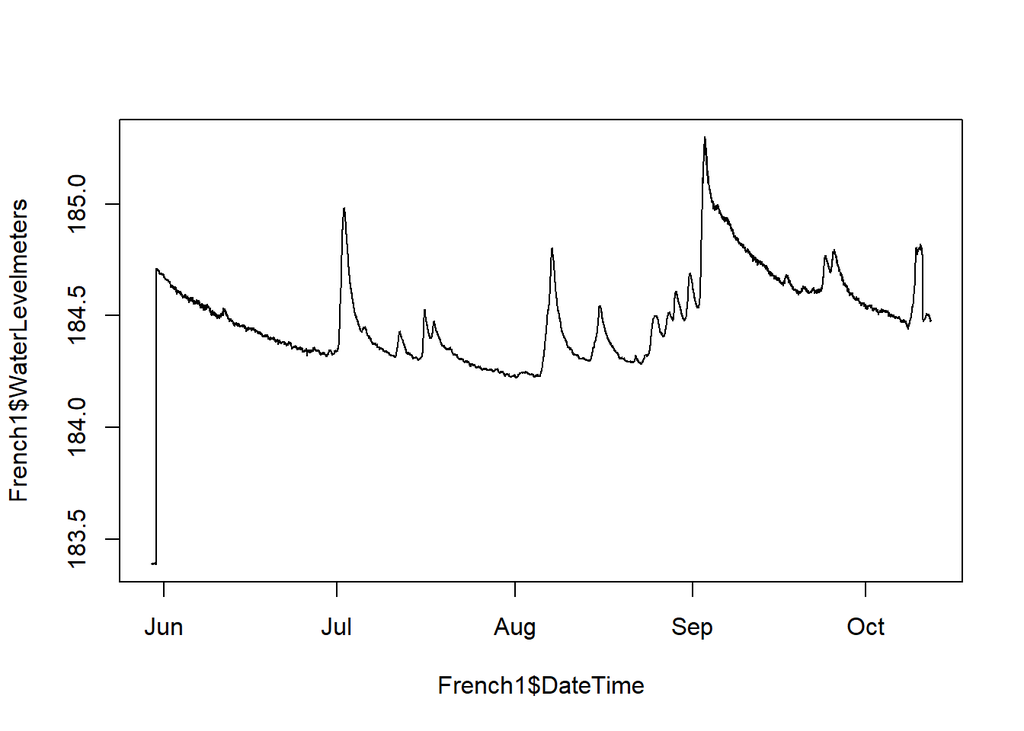

The beginning is probably when this was installed, I will remove that. the spije in October is confirmed with French 2 so that is real. let the cleaning commence!

# French PT 1 2.0

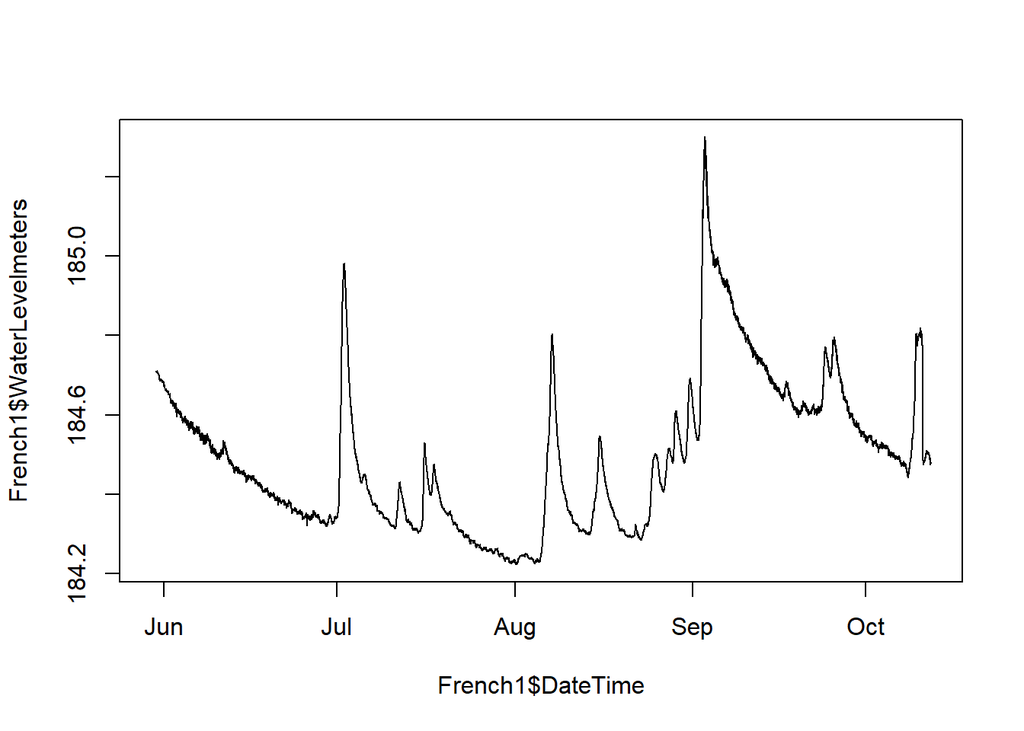

1) set the beginning of the dataframe where PT was taking out of water points to NA 2) we are dumping French PT2 due to it being too “noisy”

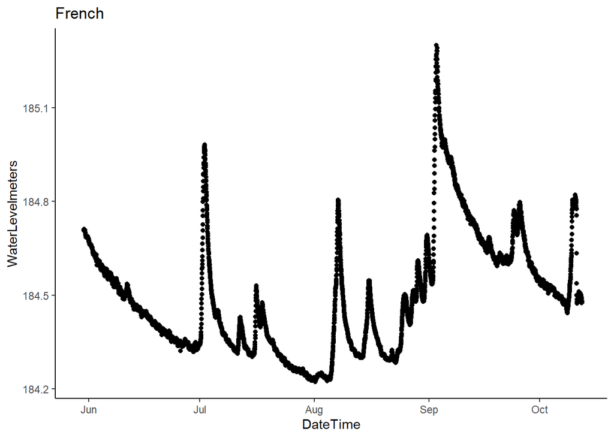

```r
French1 %>% #filter(DateTime > "2018-10-01" & DateTime < "2018-11-01") %>%
  ggplot() +
  geom_point(aes(x=DateTime, y=WaterLevelmeters)) +
  theme_classic() +
  ggtitle("French") +
  scale_color_brewer(palette = "Paired")
```

Export PT data to csv to DoD_Discharge->PT_data->2018

```
## [1] FALSE
```

### Raw Moose

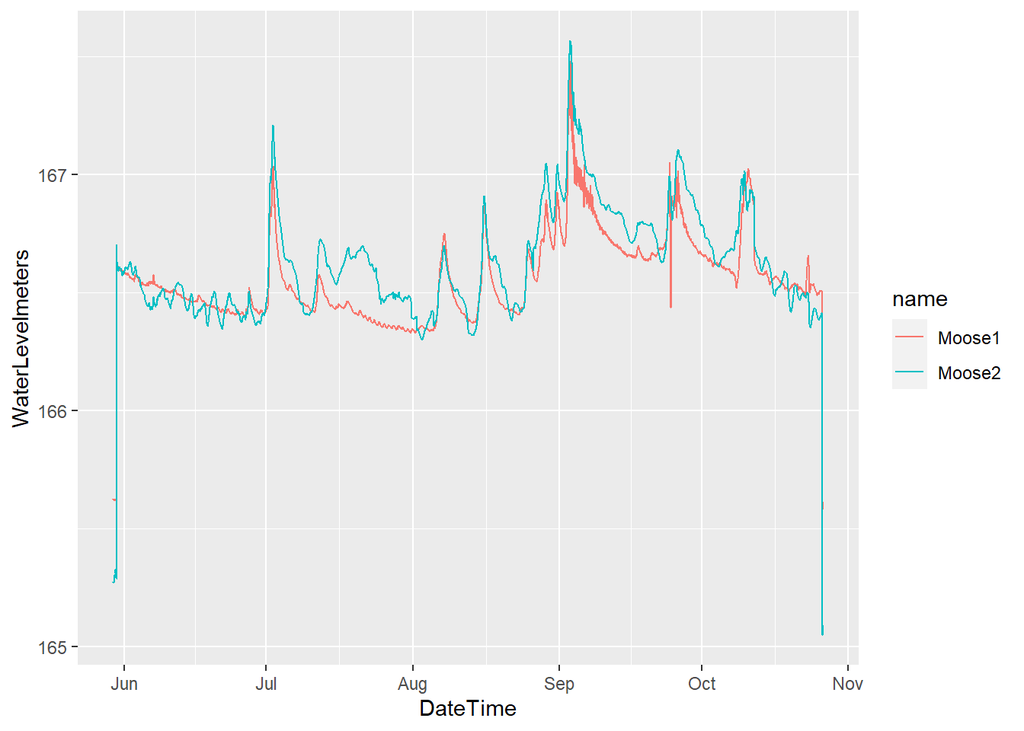

Moose2 looks a little weird during mid July, where it doens’t agree w/ Moose 1. Moose 2 seems a lot noisier….we are dumping moose 2

### Moose PT 1 2.0

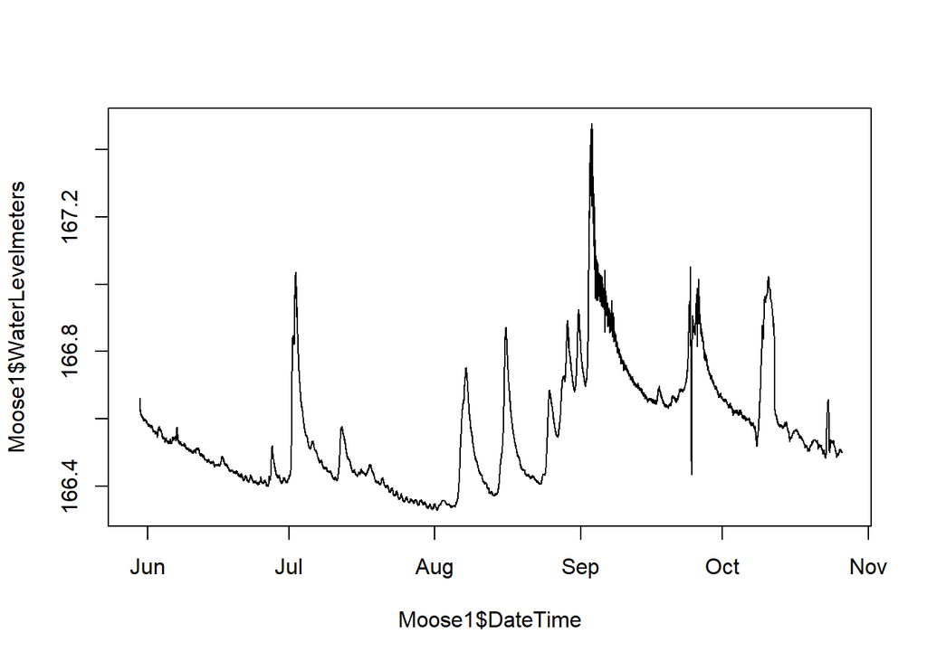

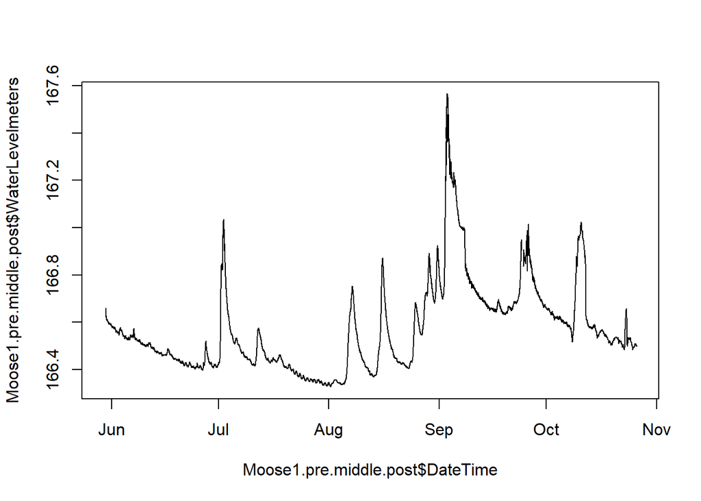

1) Removed the beginning and end of the dataframe where the PT was out of water 2) Cleaned the receding limb of the september storm and replaced it with the receding limb from the second PT however now we get a steep drop for the end of the timeseries. Should I shift the back half of the dataframe up? 3) set middle of Setember vertical drop to NAs 4) still need to do NA INTERPRET!

### Impute missing observations in pressure for MOOS

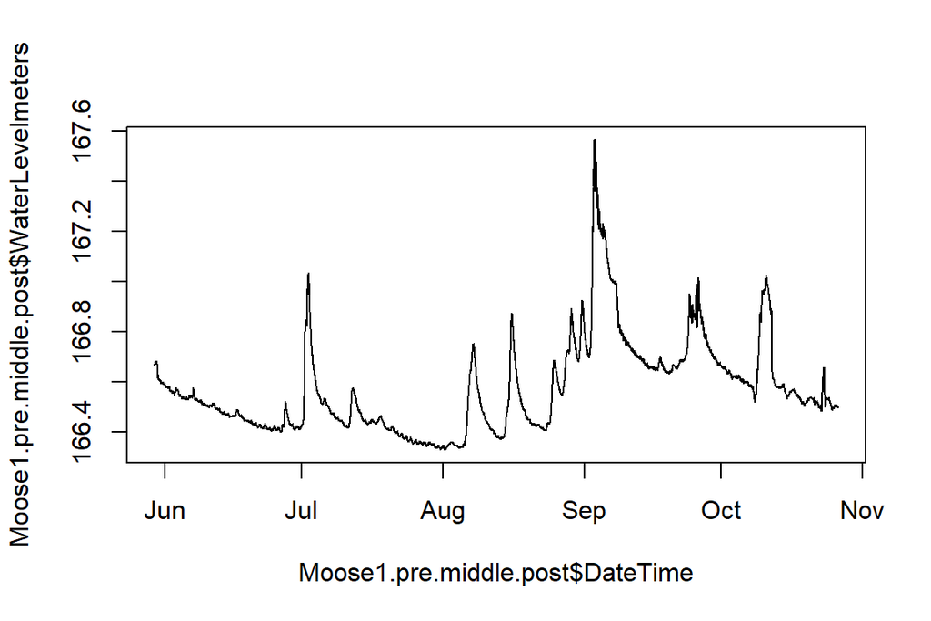

### Observed Discharge at French and Moose

- from Rachel Voight For the days we used the HOBO, there are two “measurements” since I did not know which slug solution was used, so I calculated it with the two likely slug batches. We changed where we were measuring Q at Moose; the first two times we measured Q, we did it downstream of the sensors near the actual pressure transducer. We likely underestimated Q for those few measurements at the old spot downstream of the sensors.

### export PT data to csv to DoD_Discharge->PT_data->2018

```
## [1] FALSE
```

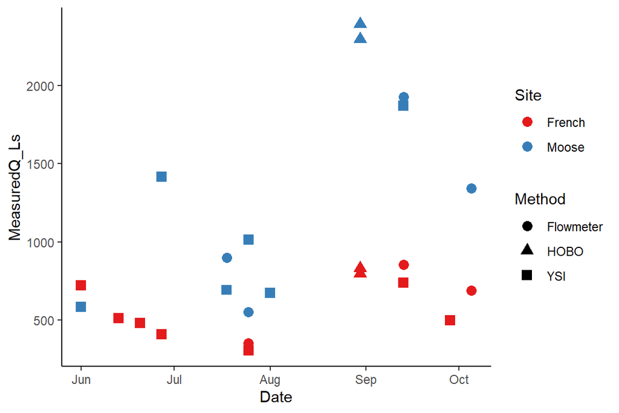

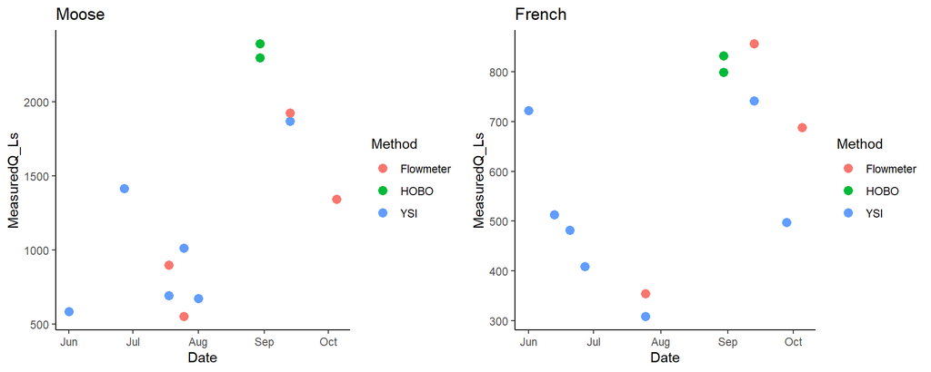

### Raw Rating Curve with Moose 1 Pressure Transducer

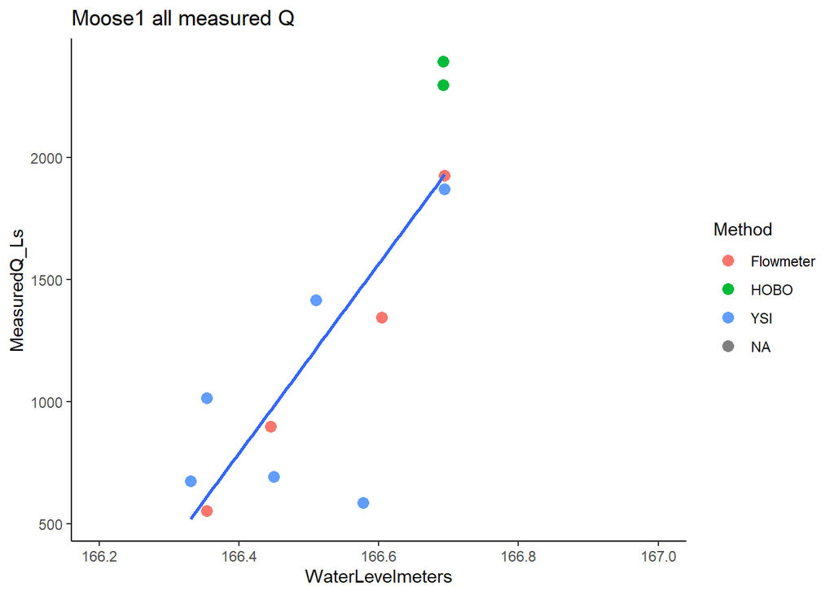

```
##
## Call:
## lm(formula = moose1comb$MeasuredQ_Ls ~ moose1comb$WaterLevelmeters)
##
## Residuals:
##     Min      1Q  Median      3Q     Max
## -892.90 -107.38  -31.09  244.17  471.74
##
## Coefficients:
##                              Estimate Std. Error t value Pr(>|t|)
## (Intercept)                 -644894.5   136300.6  -4.731 0.000802 ***
## moose1comb$WaterLevelmeters    3880.3      818.5   4.741 0.000791 ***
## ---
## Signif. codes:  0 '***' 0.001 '**' 0.01 '*' 0.05 '.' 0.1 ' ' 1
##
## Residual standard error: 392.1 on 10 degrees of freedom
##   (7193 observations deleted due to missingness)
## Multiple R-squared:  0.6921, Adjusted R-squared:  0.6613
## F-statistic: 22.48 on 1 and 10 DF,  p-value: 0.0007909
```

- Rachel -While we only had 4 measurements from the flow meter, they agree well with our trendline and slug Q. *Jake - I will remove the Hobo points in this regression

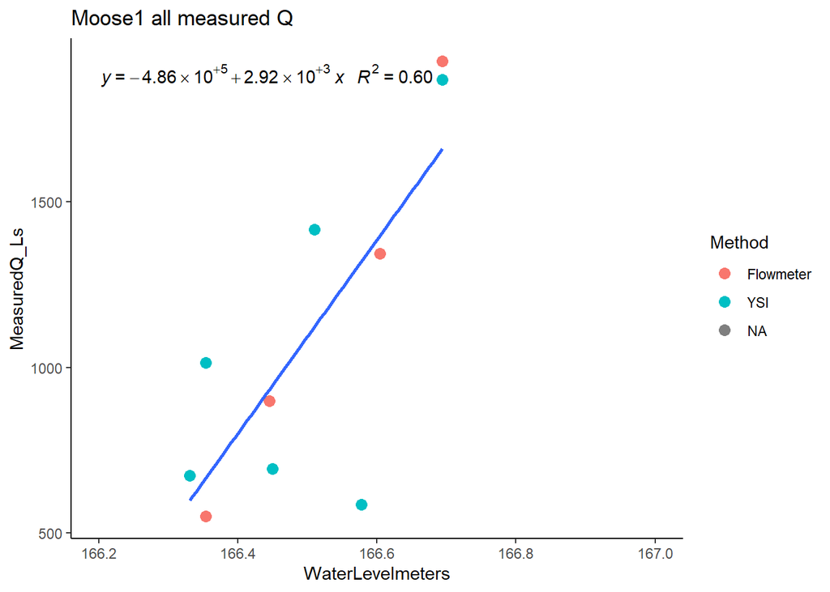

```
##
## Call:
## lm(formula = moose2comb$MeasuredQ_Ls ~ moose2comb$WaterLevelmeters)
##
## Residuals:
##     Min      1Q  Median      3Q     Max
## -734.95  -99.13   20.48  251.07  347.41
##
## Coefficients:
##                              Estimate Std. Error t value Pr(>|t|)
## (Intercept)                 -485840.1   139415.2  -3.485  0.00826 **
## moose2comb$WaterLevelmeters    2924.5      837.3   3.493  0.00817 **
## ---
## Signif. codes:  0 '***' 0.001 '**' 0.01 '*' 0.05 '.' 0.1 ' ' 1
##
## Residual standard error: 344.2 on 8 degrees of freedom
##   (7194 observations deleted due to missingness)
## Multiple R-squared:  0.6039, Adjusted R-squared:  0.5544
## F-statistic:  12.2 on 1 and 8 DF,  p-value: 0.008166
```

I will try removing that high water, low measured YSI point.

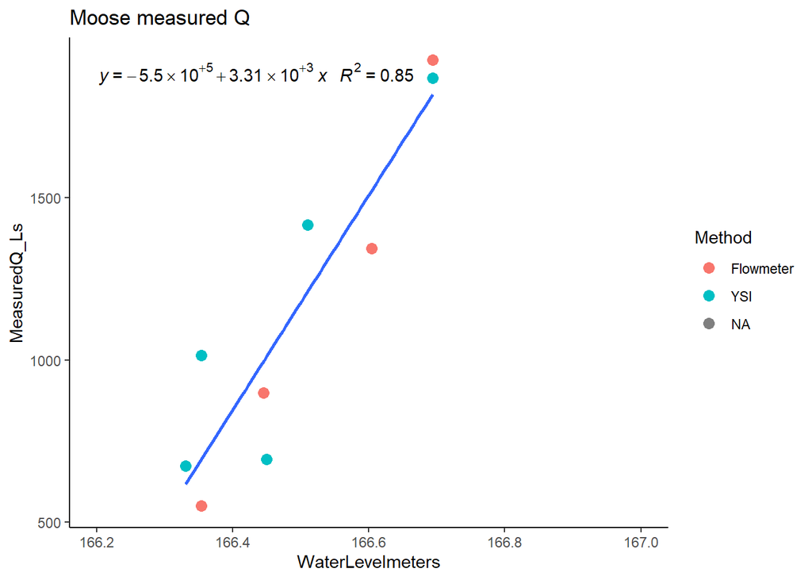

# Estimated Q from Moose 1 PT.

Black points are observed Q

```
##
## Call:
## lm(formula = moose3comb$MeasuredQ_Ls ~ moose3comb$WaterLevelmeters)
##
## Residuals:
##     Min      1Q  Median      3Q     Max
## -318.66 -142.84   49.74  106.04  319.23
##
## Coefficients:
##                              Estimate Std. Error t value Pr(>|t|)
## (Intercept)                 -549867.3    88798.6  -6.192 0.000449 ***
## moose3comb$WaterLevelmeters    3309.6      533.3   6.205 0.000443 ***
## ---
## Signif. codes:  0 '***' 0.001 '**' 0.01 '*' 0.05 '.' 0.1 ' ' 1
##
## Residual standard error: 215 on 7 degrees of freedom
##   (7195 observations deleted due to missingness)
## Multiple R-squared:  0.8462, Adjusted R-squared:  0.8242
## F-statistic: 38.51 on 1 and 7 DF,  p-value: 0.000443
```

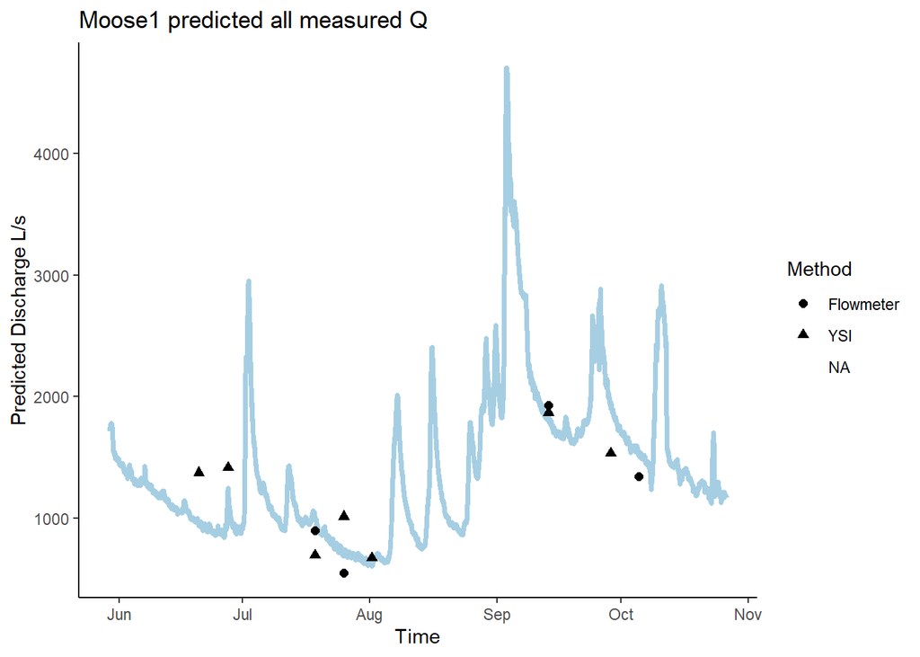

# Raw Rating Curve French 1 Pressure Transducer

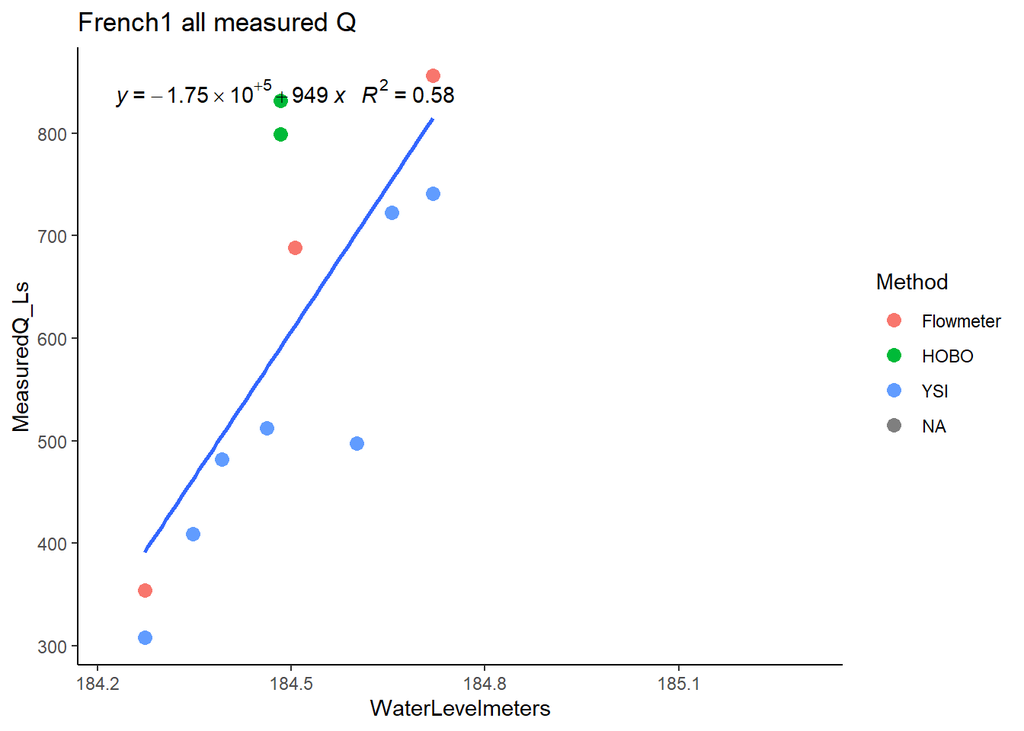

Will remove the two HOBOware points

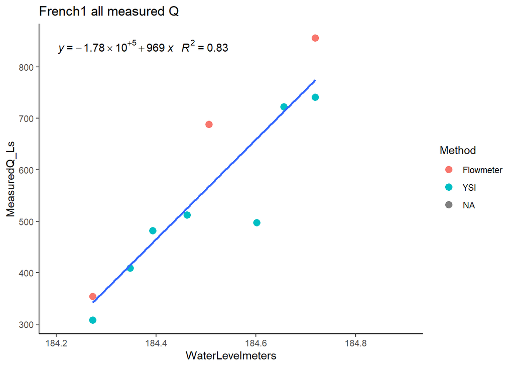

1) Removed the HOBOware points

## French 1 Calculated Q (L/s)

#### Black points are observed Q

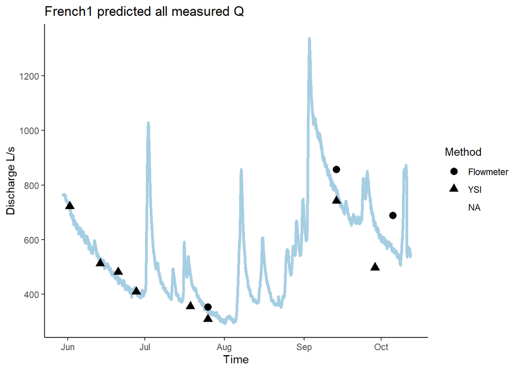

This doesnt look too shabby!

# Export 2018 PT data

```
## [1] FALSE
```

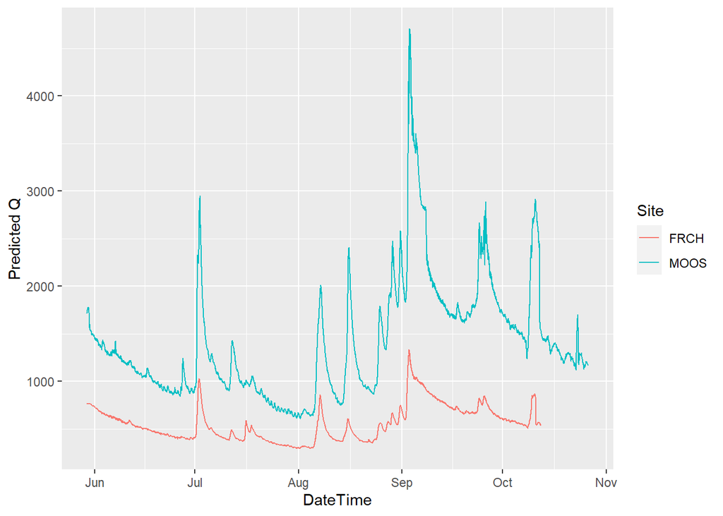

- We rock at discharge!!!

### 2019

2019 data is read from DoD->2019 AK sensors->2019 Sensor data ->PT->DoD 2019 PT depth corrected for atm  
Wading rods and slugs were used to measure discrete Q during site visit Includes all sites (Moose, French, Poker, Vault, Stuart)

2019 data is read in from DoD->2019 ak sensors->2019 sensor data->Q -> Pressure Transducer Data->Depth->‘site’

Checking closeness between the two Pressure Transducers

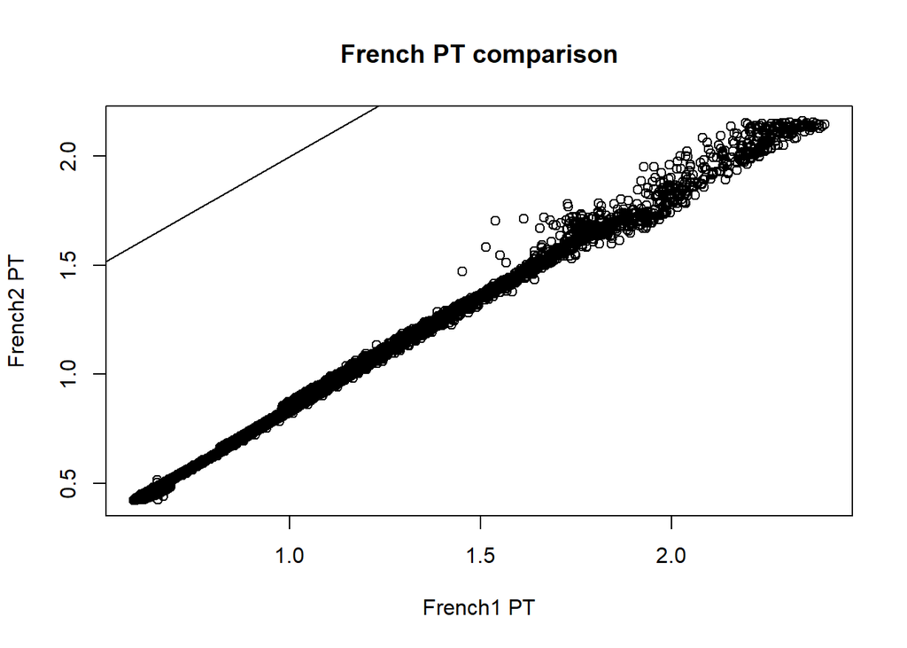

Looks pretty good

Checking Raw PT data

Raw Moose

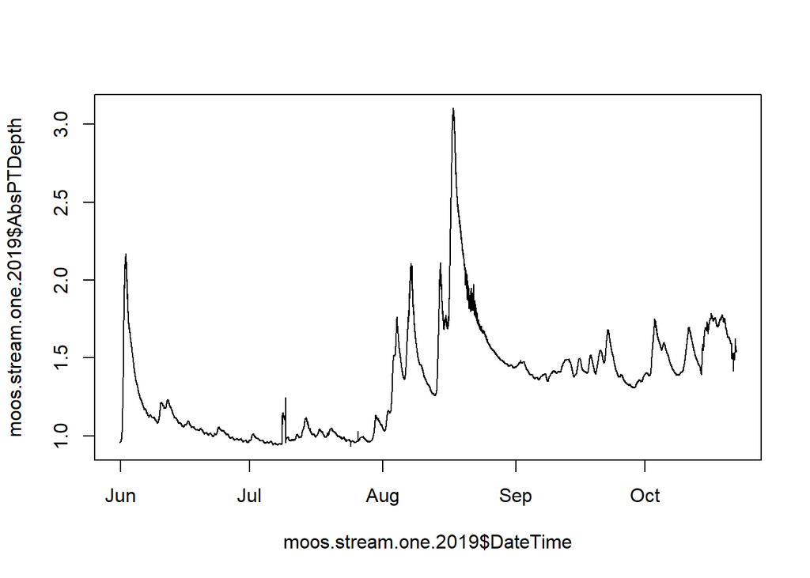

Let the cleaning commence!

## Moose 2.0

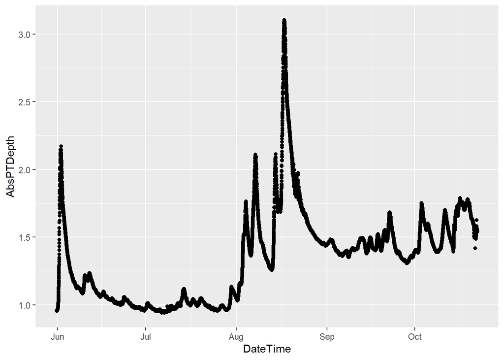

1)removed vertical bars in dataframe ? Spike in early Julyish does have rainfall close to it….is it real? Middle of October? Ice on? Should I clip middle of October, French was removed on October 10th according to the field notebook

Fill in data gaps

```r
moos.stream.one.2019 <- moos.stream.one.2019[,c(5,4)]

DateTimeFill <- data.frame(DateTime = seq(ymd_hm("
2019-05-31 15:45"),ymd_hm("2019-10-22 09:15"), by = '15 mins'))
moos.stream.one.2019 <- full_join(moos.stream.one.2019, DateTimeFill)
moos.stream.one.2019 <- moos.stream.one.2019[order(moos.stream.one.2019$DateTime),]
moos.stream.one.2019 <- na_kalman(moos.stream.one.2019)
```

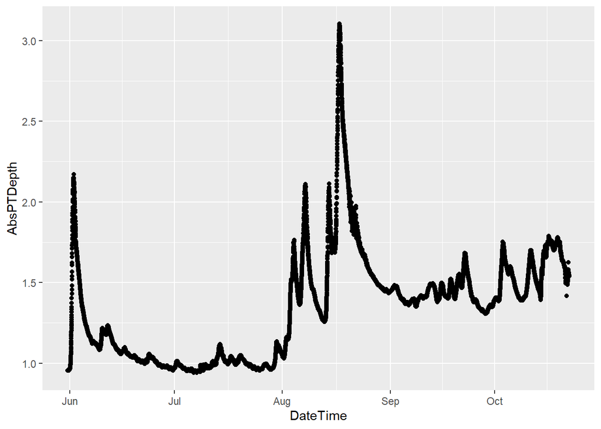

```r
moos.stream.one.2019$Site <- rep("MOOS", length(moos.stream.one.2019$DateTime))

ggplot(moos.stream.one.2019, aes(x = DateTime, y = AbsPTDepth)) +
  geom_point()
```

# Observed Discharge at all sites

Slugs and wading rods were used for 2019 observed Q

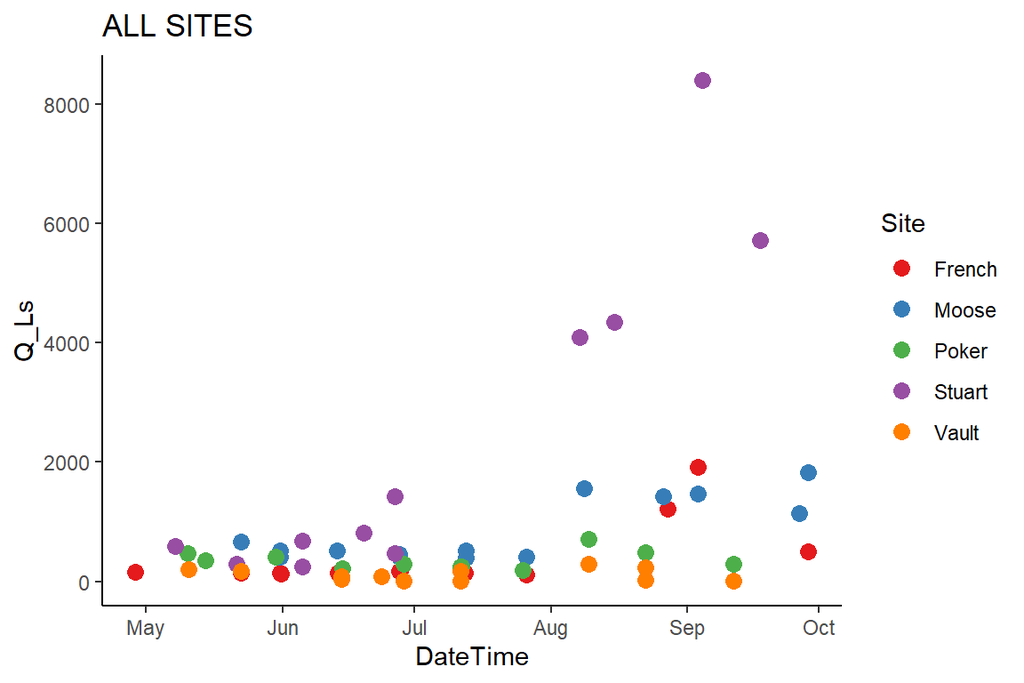

Raw Rating Curve with Moose 1 Pressure Transducer

```
##
## Call:
## lm(formula = Moose1comb.2019$Q_Ls ~ Moose1comb.2019$AbsPTDepth)
##
## Residuals:
##     Min      1Q  Median      3Q     Max
## -244.52  -99.52  -40.47    8.89  695.85
##
## Coefficients:
##                            Estimate Std. Error t value Pr(>|t|)
## (Intercept)                 -1422.1      334.3  -4.255  0.00136 **
## Moose1comb.2019$AbsPTDepth   1943.1      279.7   6.948 2.43e-05 ***
## ---
## Signif. codes:  0 '***' 0.001 '**' 0.01 '*' 0.05 '.' 0.1 ' ' 1
##
## Residual standard error: 244 on 11 degrees of freedom
##   (13821 observations deleted due to missingness)
## Multiple R-squared:  0.8144, Adjusted R-squared:  0.7976
## F-statistic: 48.28 on 1 and 11 DF,  p-value: 2.429e-05
```

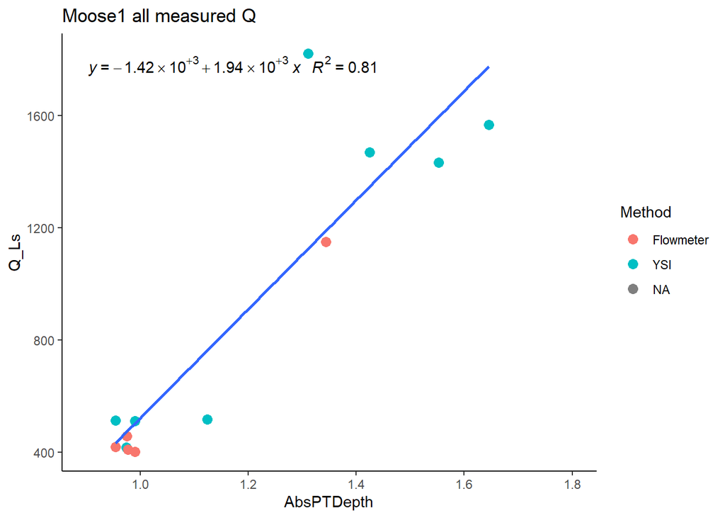

Not too shabby, I’m going to remove the top YSI point.

```
##
## Call:
## lm(formula = Moose2comb.2019$Q_Ls ~ Moose2comb.2019$AbsPTDepth)
##
## Residuals:
##      Min       1Q   Median       3Q      Max
## -191.511  -53.732   -3.873   43.048  217.244
##
## Coefficients:
##                            Estimate Std. Error t value Pr(>|t|)
## (Intercept)                 -1314.2      147.8  -8.889 4.63e-06 ***
## Moose2comb.2019$AbsPTDepth   1799.9      124.8  14.427 5.08e-08 ***
## ---
## Signif. codes:  0 '***' 0.001 '**' 0.01 '*' 0.05 '.' 0.1 ' ' 1
##
## Residual standard error: 107.3 on 10 degrees of freedom
##   (13822 observations deleted due to missingness)
## Multiple R-squared:  0.9542, Adjusted R-squared:  0.9496
## F-statistic: 208.1 on 1 and 10 DF,  p-value: 5.079e-08
```

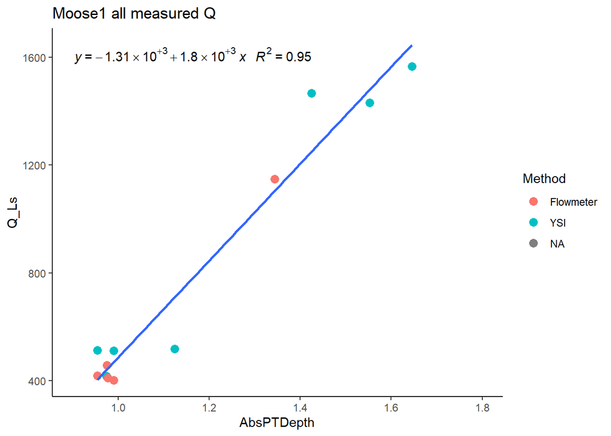

That’s better, I will use this for the predicted discharge

# Predicted Q MOOS PT1

Black points are observed Q

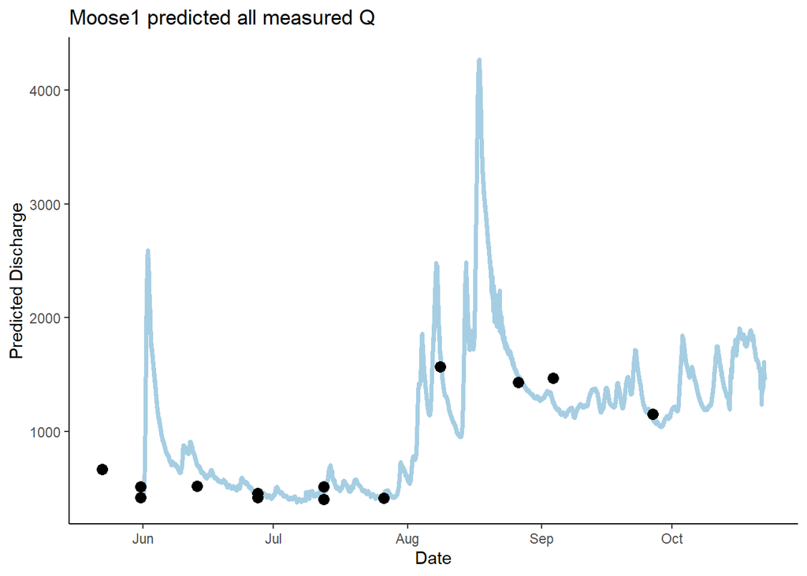

Not too shabby

### export PT data to csv to DoD_Discharge->Predicted_Discharge->2019

## Raw French PT1

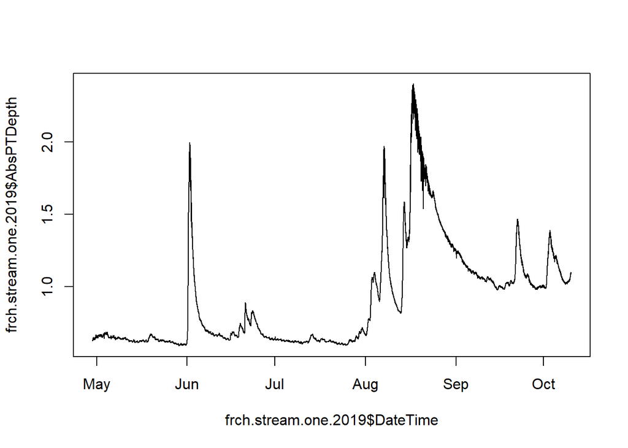

Looks good. I am going to replace the noisy-ness of the receding limb in the big august storm with FRCH PT2 as it is less noisy let the cleaning commence!

# FRCH PT1 2.0

```
## [1] 10549
```

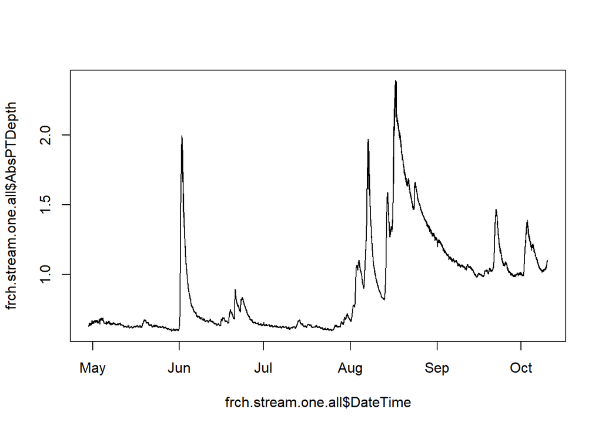

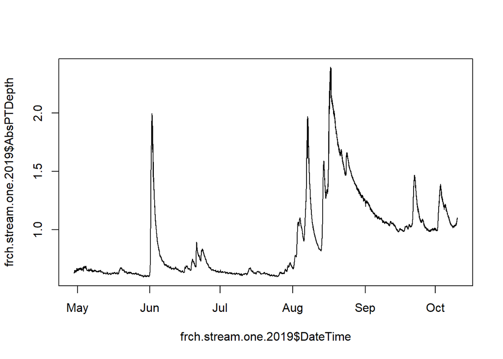

1) replaced the noisy receding limb in the big end of August storm of PT1 with the more constant data of PT2